# Acoustic telemetry exploratory analysis

Automatically generated by actel

### Summary

Selected folder: C:/Users/hdmfla/Documents/GitHub/RSP/Limfjord_tester

Timestamp: **2019-11-29 11:49:06**

Number of target tags: **5**

Number of listed receivers: **9** (of which **1** had no detections)

Data time range: 2018-02-11 20:27:37 to 2018-08-31 15:43:46 (Europe/Copenhagen).

Percentage of post-release valid detections: 100%

Found a bug? [**Report it here.**](https://github.com/hugomflavio/actel/issues)

### Study area

Release sites are marked with “R.S.”. Arrays connected with an arrow indicate that the fish can only pass in one direction.

[figure not shown]

### Receiver stations

| Station.Name | Latitude | Longitude | Array | Standard.Name |
| --- | --- | --- | --- | --- |
| Simested | 56.57160 | 9.380188 | Simested | St.1 |
| Sundstrup1 | 56.60531 | 9.292661 | Sundstrup | St.2 |
| Sundstrup2 | 56.60819 | 9.291788 | Sundstrup | St.3 |
| Hvalpsund | 56.70344 | 9.186914 | Hvalpsund | St.4 |
| Aggersund | 57.00003 | 9.292732 | Aggersund | St.5 |
| 15 Aalborg1 | 57.05408 | 9.915390 | 15Aalborg | St.6 |
| 16 Aalborg2 | 57.05595 | 9.921725 | 16Aalborg | St.7 |
| Hals1 | 56.98947 | 10.310159 | Hals1 | St.8 |
| Hals2 | 56.98583 | 10.310770 | Hals2 | St.9 |

### Deployments

| Receiver | Station.Name | Start | Stop |
| --- | --- | --- | --- |
| 108766 | 16 Aalborg2 | 2018-02-11 20:27:36 | 2018-08-31 15:43:47 |
| 108768 | Hals2 | 2018-02-11 20:27:36 | 2018-08-31 15:43:47 |
| 125447 | 15 Aalborg1 | 2018-02-11 20:27:36 | 2018-08-31 15:43:47 |
| 125449 | Simested | 2018-02-11 20:27:36 | 2018-08-31 15:43:47 |
| 125452 | Hals1 | 2018-02-11 20:27:36 | 2018-08-31 15:43:47 |
| 125886 | Aggersund | 2018-02-11 20:27:36 | 2018-08-31 15:43:47 |
| 131090 | Sundstrup1 | 2018-02-11 20:27:36 | 2018-08-31 15:43:47 |
| 131092 | Sundstrup2 | 2018-02-11 20:27:36 | 2018-08-31 15:43:47 |
| 408 | Hvalpsund | 2018-02-11 20:27:36 | 2018-08-31 15:43:47 |

### Release sites

| Station.Name | Longitude | Latitude | Array | Standard.Name |
| --- | --- | --- | --- | --- |
| unspecified | NA | NA | Simested | unspecified |

### Warning messages

```
W: File 'detections/Thelma.csv' does not match to any of the supported hydrophone file formats!
   If your file corresponds to a hydrophone log and actel did not recognize it, please get in contact through www.github.com/hugomflavio/actel/issues/new
W: No detections were found for receiver(s) 408.
Error: Fish R64K-4080 was detected before being released!
M: 42 detections from Fish R64K-4080 were removed per user command.
W: Fish R64K-4080 jumped through 6 arrays from release to first event (Release -> Hals1).
M: 'speed.warning'/'speed.error' were not set, skipping speed checks.
M: 'inactive.warning'/'inactive.error' were not set, skipping inactivity checks.
```

### Average time of arrival at each Array

**Note:**

Coloured lines on the outer circle indicate the mean value for each group and the respective ranges show the standard error of the mean. Each group’s bars sum to 100%. The number of data points in each group is presented between brackets in the legend of each pannel.

[figure not shown]

### Individual plots

**Note:**

The detections are coloured by array. The vertical black dashed line shows the time of release. The dashed dark-grey line shows the generated movement events.

The movement event lines move straight between the first and last station of each event (i.e. in-between detections will not be individually linked by the line).

Manually **edited** fish are highlighted with **yellow** graphic borders.

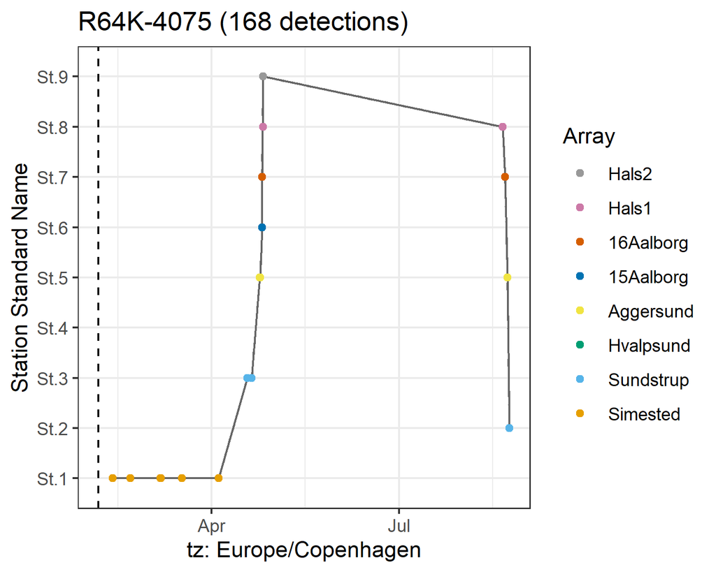

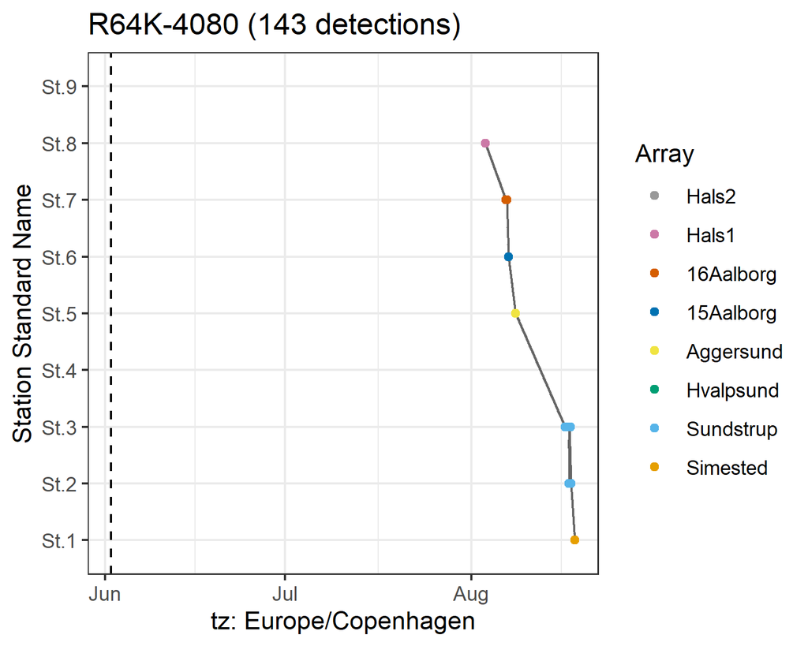

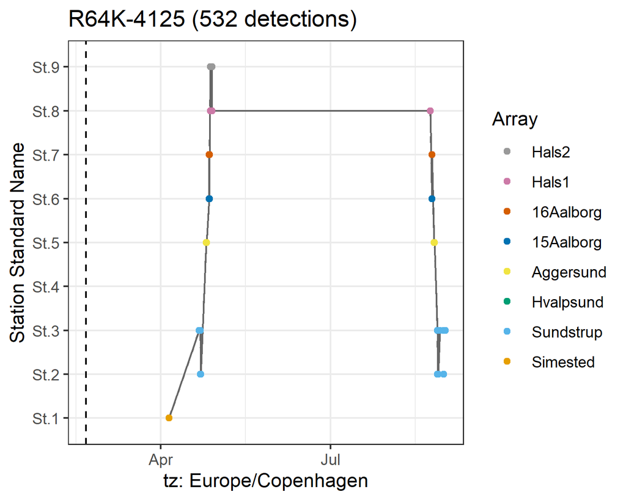

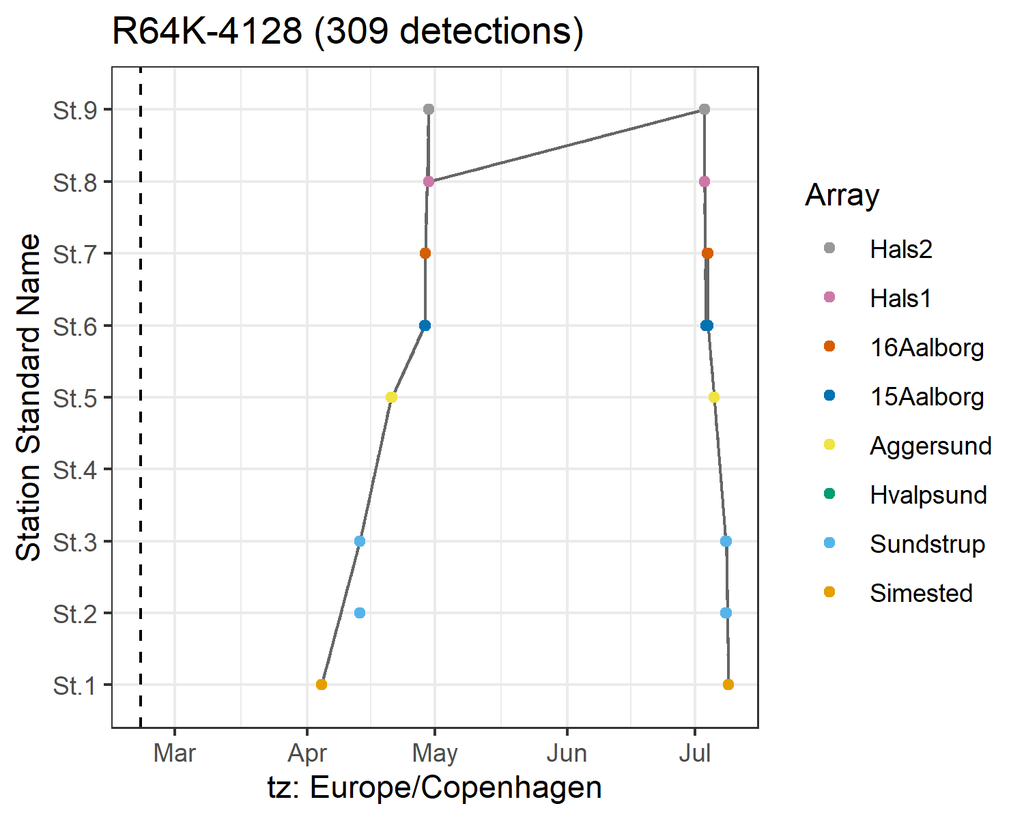

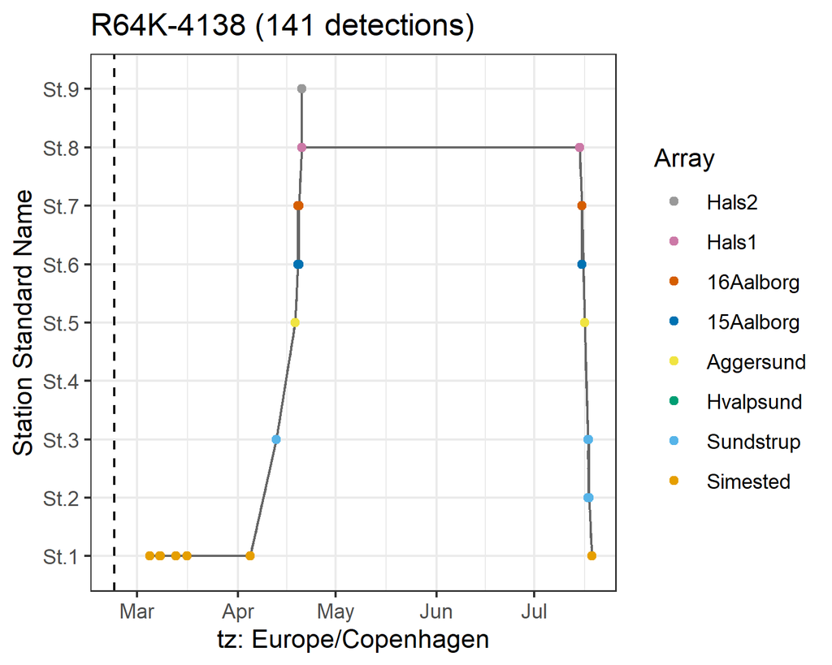

### Full log

[output not shown]